# One Big European League

by Henry Herrera

Lets predict if the top 5 leagues in European soccer played in one league all together who would win. Since all the top leagues in Europe have paused for the world cup, it seemed interesting to see if there was a world cup style season but with clubs from the top european leagues. The season would be similar to what a regular season is. So the winner would be whoever comes in first place. To predict the winner we will be using last seasons stats from all the top European leagues. We also be using this seasons stats.

```python
import pandas as pd
import numpy as np
import matplotlib.pyplot as plt
import seaborn as sns
from sklearn import tree
from sklearn.ensemble import RandomForestClassifier
from sklearn.model_selection import train_test_split
from sklearn.metrics import confusion_matrix
```

For this project we will be usng: Pandas Numby Pyplot Seasborn SKlearn

# Data Collection/Representation

```python
team_stats_df = pd.read_csv('2021-2022 Football Team Stats.csv', sep = ';', encoding = "ISO-8859-1")
player_stats_df = pd.read_csv('2021-2022 Football Player Stats.csv', sep = ';', encoding = "ISO-8859-1")
```

Starting off we load our datasets that we will be using in our analysis. Note these datasets are based on the 2021-2022 season. The team_stats_df dataset represent the team stats. The second dataset represents the players stats.

```python
team_stats_df.head(10)
```

|  | Rk | Squad | Country | LgRk | MP | W | D | L | GF | GA | GD | Pts | Pts/G | xG | xGA | xGD | xGD/90 | Attendance | Top Team Scorer | Goalkeeper |
| --- | --- | --- | --- | --- | --- | --- | --- | --- | --- | --- | --- | --- | --- | --- | --- | --- | --- | --- | --- | --- |
| 0 | 1 | Manchester City | ENG | 1 | 38 | 29 | 6 | 3 | 99 | 26 | 73 | 93 | 2.45 | 89.0 | 27.2 | 61.9 | 1.63 | 52774 | Kevin De Bruyne - 15 | Ederson |
| 1 | 2 | Liverpool | ENG | 2 | 38 | 28 | 8 | 2 | 94 | 26 | 68 | 92 | 2.42 | 89.2 | 34.2 | 55.0 | 1.45 | 53367 | Mohamed Salah - 23 | Alisson |
| 2 | 3 | Bayern Munich | GER | 1 | 34 | 24 | 5 | 5 | 97 | 37 | 60 | 77 | 2.26 | 88.1 | 37.1 | 51.0 | 1.50 | 33176 | Robert Lewandowski - 35 | Manuel Neuer |
| 3 | 4 | Paris S-G | FRA | 1 | 38 | 26 | 8 | 4 | 90 | 36 | 54 | 86 | 2.26 | 76.5 | 38.6 | 37.9 | 1.00 | 41188 | Kylian Mbappé - 28 | Keylor Navas |
| 4 | 5 | Real Madrid | ESP | 1 | 38 | 26 | 8 | 4 | 80 | 31 | 49 | 86 | 2.26 | 74.3 | 47.0 | 27.3 | 0.72 | 41235 | Karim Benzema - 27 | Thibaut Courtois |
| 5 | 6 | Milan | ITA | 1 | 38 | 26 | 8 | 4 | 69 | 31 | 38 | 86 | 2.26 | 63.1 | 34.8 | 28.3 | 0.74 | 42388 | Olivier Giroud Rafael Leão - 11 | Mike Maignan |
| 6 | 7 | Inter | ITA | 2 | 38 | 25 | 9 | 4 | 84 | 32 | 52 | 84 | 2.21 | 81.4 | 39.2 | 42.2 | 1.11 | 41407 | Lautaro Martínez - 21 | Samir Handanovi? |
| 7 | 8 | Napoli | ITA | 3 | 38 | 24 | 7 | 7 | 74 | 31 | 43 | 79 | 2.08 | 59.4 | 31.9 | 27.6 | 0.73 | 26681 | Victor Osimhen - 14 | David Ospina |
| 8 | 9 | Dortmund | GER | 2 | 34 | 22 | 3 | 9 | 85 | 52 | 33 | 69 | 2.03 | 62.8 | 43.2 | 19.6 | 0.58 | 41800 | Erling Haaland - 22 | Gregor Kobel |
| 9 | 10 | Chelsea | ENG | 3 | 38 | 21 | 11 | 6 | 76 | 33 | 43 | 74 | 1.95 | 67.2 | 36.0 | 31.3 | 0.82 | 36443 | Mason Mount - 11 | Edouard Mendy |

```python
team_stats_df.drop(columns = ['Pts/G','xG','xGA','xGD','xGD/90','Attendance','Top Team Scorer', 'Goalkeeper'], inplace = True)
team_stats_df.head(10)
```

|  | Rk | Squad | Country | LgRk | MP | W | D | L | GF | GA | GD | Pts |
| --- | --- | --- | --- | --- | --- | --- | --- | --- | --- | --- | --- | --- |
| 0 | 1 | Manchester City | ENG | 1 | 38 | 29 | 6 | 3 | 99 | 26 | 73 | 93 |
| 1 | 2 | Liverpool | ENG | 2 | 38 | 28 | 8 | 2 | 94 | 26 | 68 | 92 |
| 2 | 3 | Bayern Munich | GER | 1 | 34 | 24 | 5 | 5 | 97 | 37 | 60 | 77 |
| 3 | 4 | Paris S-G | FRA | 1 | 38 | 26 | 8 | 4 | 90 | 36 | 54 | 86 |
| 4 | 5 | Real Madrid | ESP | 1 | 38 | 26 | 8 | 4 | 80 | 31 | 49 | 86 |
| 5 | 6 | Milan | ITA | 1 | 38 | 26 | 8 | 4 | 69 | 31 | 38 | 86 |
| 6 | 7 | Inter | ITA | 2 | 38 | 25 | 9 | 4 | 84 | 32 | 52 | 84 |
| 7 | 8 | Napoli | ITA | 3 | 38 | 24 | 7 | 7 | 74 | 31 | 43 | 79 |
| 8 | 9 | Dortmund | GER | 2 | 34 | 22 | 3 | 9 | 85 | 52 | 33 | 69 |
| 9 | 10 | Chelsea | ENG | 3 | 38 | 21 | 11 | 6 | 76 | 33 | 43 | 74 |

We are dropping columns that we will not use in the team_stats_df. We we will use in this dataset is:  
Rk: Rank  
Squad: Team Name  
Country: Teams Country Origin  
LgRk: Rank in thier respective league  
MP: Matches played  
W: Wins  
D: Draws  
L: Lose  
GF: Goals Forced aka scored  
GA: Goals Allowed aka conceded  
GD: Goal Differential (GF - GD)  
Pts: Points  
Data set can be found [here](https://www.kaggle.com/datasets/vivovinco/20212022-football-team-stats)

```python
player_stats_df.head(10)
```

|  | Rk | Player | Nation | Pos | Squad | Comp | Age | Born | MP | Starts | ... | Off | Crs | TklW | PKwon | PKcon | OG | Recov | AerWon | AerLost | AerWon% |
| --- | --- | --- | --- | --- | --- | --- | --- | --- | --- | --- | --- | --- | --- | --- | --- | --- | --- | --- | --- | --- | --- |
| 0 | 1 | Max Aarons | ENG | DF | Norwich City | Premier League | 22.0 | 2000 | 34 | 32 | ... | 0.03 | 1.41 | 1.16 | 0.00 | 0.06 | 0.03 | 5.53 | 0.47 | 1.59 | 22.7 |
| 1 | 2 | Yunis Abdelhamid | MAR | DF | Reims | Ligue 1 | 34.0 | 1987 | 34 | 34 | ... | 0.00 | 0.06 | 1.39 | 0.00 | 0.03 | 0.00 | 6.77 | 2.02 | 1.36 | 59.8 |
| 2 | 3 | Salis Abdul Samed | GHA | MF | Clermont Foot | Ligue 1 | 22.0 | 2000 | 31 | 29 | ... | 0.00 | 0.36 | 1.24 | 0.00 | 0.00 | 0.00 | 8.76 | 0.88 | 0.88 | 50.0 |
| 3 | 4 | Laurent Abergel | FRA | MF | Lorient | Ligue 1 | 29.0 | 1993 | 34 | 34 | ... | 0.03 | 0.79 | 2.23 | 0.00 | 0.00 | 0.00 | 8.87 | 0.43 | 0.43 | 50.0 |
| 4 | 5 | Charles Abi | FRA | FW | Saint-Étienne | Ligue 1 | 22.0 | 2000 | 1 | 1 | ... | 0.00 | 2.00 | 0.00 | 0.00 | 0.00 | 0.00 | 4.00 | 2.00 | 0.00 | 100.0 |
| 5 | 6 | Dickson Abiama | NGA | FW | Greuther Fürth | Bundesliga | 23.0 | 1998 | 24 | 5 | ... | 1.85 | 0.25 | 0.86 | 0.00 | 0.00 | 0.00 | 4.81 | 2.72 | 4.94 | 35.5 |
| 6 | 7 | Matthis Abline | FRA | FW | Rennes | Ligue 1 | 19.0 | 2003 | 7 | 1 | ... | 0.00 | 0.91 | 0.00 | 0.00 | 0.00 | 0.00 | 6.36 | 0.00 | 1.82 | 0.0 |
| 7 | 8 | Tammy Abraham | ENG | FW | Roma | Serie A | 24.0 | 1997 | 37 | 36 | ... | 0.50 | 0.70 | 0.64 | 0.03 | 0.03 | 0.00 | 3.67 | 2.39 | 2.89 | 45.3 |
| 8 | 9 | Luis Abram | PER | DF | Granada | La Liga | 26.0 | 1996 | 8 | 6 | ... | 0.00 | 0.00 | 0.97 | 0.00 | 0.00 | 0.16 | 4.03 | 1.94 | 2.42 | 44.4 |
| 9 | 10 | Francesco Acerbi | ITA | DF | Lazio | Serie A | 34.0 | 1988 | 30 | 29 | ... | 0.14 | 0.04 | 0.43 | 0.04 | 0.00 | 0.00 | 10.70 | 2.84 | 1.60 | 64.0 |

10 rows × 143 columns

```python
len(player_stats_df.columns)
```

```
143
```

Note the player stats dataset has a lot of columns. We are not going to use all of them.

```python
player_complete_stats_df = player_stats_df[['Squad', 'Goals','Min', 'Shots', 'SoT','PasTotCmp','PasTotAtt','Assists','PasAss','SCA','GCA','DriSucc','DriAtt']]
player_complete_stats_df.head(10)
```

|  | Squad | Goals | Min | Shots | SoT | PasTotCmp | PasTotAtt | Assists | PasAss | SCA | GCA | DriSucc | DriAtt |
| --- | --- | --- | --- | --- | --- | --- | --- | --- | --- | --- | --- | --- | --- |
| 0 | Norwich City | 0.00 | 2881 | 0.41 | 0.06 | 34.00 | 45.00 | 0.06 | 0.59 | 1.19 | 0.16 | 1.03 | 2.44 |
| 1 | Reims | 0.06 | 2983 | 0.54 | 0.18 | 38.70 | 47.00 | 0.00 | 0.24 | 0.63 | 0.03 | 0.48 | 0.66 |
| 2 | Clermont Foot | 0.04 | 2462 | 0.66 | 0.18 | 55.90 | 61.00 | 0.00 | 0.55 | 1.46 | 0.04 | 0.99 | 1.53 |
| 3 | Lorient | 0.00 | 2956 | 0.91 | 0.21 | 40.70 | 49.80 | 0.06 | 0.91 | 2.01 | 0.15 | 1.28 | 1.98 |
| 4 | Saint-Étienne | 0.00 | 45 | 0.00 | 0.00 | 4.00 | 12.00 | 0.00 | 0.00 | 0.00 | 0.00 | 0.00 | 0.00 |
| 5 | Greuther Fürth | 0.00 | 726 | 2.22 | 0.49 | 11.10 | 17.20 | 0.12 | 0.99 | 2.47 | 0.25 | 0.74 | 2.22 |
| 6 | Rennes | 0.00 | 103 | 1.82 | 0.00 | 7.27 | 9.09 | 0.00 | 0.91 | 0.91 | 0.00 | 0.91 | 1.82 |
| 7 | Roma | 0.50 | 3084 | 2.71 | 0.93 | 14.60 | 20.20 | 0.12 | 1.02 | 2.33 | 0.35 | 1.08 | 2.22 |
| 8 | Granada | 0.00 | 560 | 0.32 | 0.00 | 31.30 | 35.50 | 0.00 | 0.00 | 0.48 | 0.16 | 0.00 | 0.00 |
| 9 | Lazio | 0.14 | 2536 | 0.57 | 0.25 | 64.30 | 71.10 | 0.00 | 0.21 | 0.64 | 0.07 | 0.11 | 0.14 |

Again we drop columns that will not be in use for the players stats. What is left in the data set is:  
Goals: Goals Per 90 min  
Min: Minutes played  
Shot: Shots Per 90 min  
SoT: Shots on Target per 90 min  
PasTotCmp: Pass Total Completions Per 90 min  
PasTotATT: Pass Total Attempts Per 90 min  
Assists: Assists per 90 min  
PasAss: Pass leading to assists total per 90min  
SCA: Shot creating action per 90  
GCA: Goal creating Action per 90  
DriSucc: Dribbling Success per 90  
DriAtt: Dribble Attempts per 90  
Dataset can be found here

```python
for i,d in player_stats_df.iterrows():
    player_complete_stats_df.at[i,'Goals'] = round((d['Goals'] * d['Min']) / 90)
    player_complete_stats_df.at[i,'Assists'] = round((d['Assists'] * d['Min']) / 90)
    player_complete_stats_df.at[i,'Shots'] = round((d['Shots'] * d['Min']) / 90)
    player_complete_stats_df.at[i,'PasTotCmp'] = round((d['PasTotCmp'] * d['Min']) / 90)
    player_complete_stats_df.at[i,'PasTotAtt'] = round((d['PasTotAtt'] * d['Min']) / 90)
    player_complete_stats_df.at[i,'SCA'] = round((d['SCA'] * d['Min']) / 90)
    player_complete_stats_df.at[i,'GCA'] = round((d['GCA'] * d['Min']) / 90)
    player_complete_stats_df.at[i,'DriSucc'] = round((d['DriSucc'] * d['Min']) / 90)
    player_complete_stats_df.at[i,'DriAtt'] = round((d['DriAtt'] * d['Min']) / 90)

player_complete_stats_df.head(10)
```

|  | Squad | Goals | Min | Shots | SoT | PasTotCmp | PasTotAtt | Assists | PasAss | SCA | GCA | DriSucc | DriAtt |
| --- | --- | --- | --- | --- | --- | --- | --- | --- | --- | --- | --- | --- | --- |
| 0 | Norwich City | 0.0 | 2881 | 13.0 | 0.06 | 1088.0 | 1440.0 | 2.0 | 0.59 | 38.0 | 5.0 | 33.0 | 78.0 |
| 1 | Reims | 2.0 | 2983 | 18.0 | 0.18 | 1283.0 | 1558.0 | 0.0 | 0.24 | 21.0 | 1.0 | 16.0 | 22.0 |
| 2 | Clermont Foot | 1.0 | 2462 | 18.0 | 0.18 | 1529.0 | 1669.0 | 0.0 | 0.55 | 40.0 | 1.0 | 27.0 | 42.0 |
| 3 | Lorient | 0.0 | 2956 | 30.0 | 0.21 | 1337.0 | 1636.0 | 2.0 | 0.91 | 66.0 | 5.0 | 42.0 | 65.0 |
| 4 | Saint-Étienne | 0.0 | 45 | 0.0 | 0.00 | 2.0 | 6.0 | 0.0 | 0.00 | 0.0 | 0.0 | 0.0 | 0.0 |
| 5 | Greuther Fürth | 0.0 | 726 | 18.0 | 0.49 | 90.0 | 139.0 | 1.0 | 0.99 | 20.0 | 2.0 | 6.0 | 18.0 |
| 6 | Rennes | 0.0 | 103 | 2.0 | 0.00 | 8.0 | 10.0 | 0.0 | 0.91 | 1.0 | 0.0 | 1.0 | 2.0 |
| 7 | Roma | 17.0 | 3084 | 93.0 | 0.93 | 500.0 | 692.0 | 4.0 | 1.02 | 80.0 | 12.0 | 37.0 | 76.0 |
| 8 | Granada | 0.0 | 560 | 2.0 | 0.00 | 195.0 | 221.0 | 0.0 | 0.00 | 3.0 | 1.0 | 0.0 | 0.0 |
| 9 | Lazio | 4.0 | 2536 | 16.0 | 0.25 | 1812.0 | 2003.0 | 0.0 | 0.21 | 18.0 | 2.0 | 3.0 | 4.0 |

Earlier it was mentioned that the player stats dataset had stats that were based on the per 90 ratio. Its not gonna be explain much here, but more details about the per 90 ration can be found [here](https://www.coachtechsoccer.com/wp-content/uploads/2021/04/Best-Practice-Task-CoachTech-Opposition-Analysis-Data-Course.pdf). So to find the actual stat totals for each player we do, (x * MinutesPlayed) / 90, where x is the per90 ratio for the stat you wanna find. After thats done you see each player now has a resonable stat total for the season.

```python
player_complete_stats_df['Goals'].max()
```

```
35.0
```

Note if you see the max goals scored by a player for all the leagues has 35. Which was done by Robert Lewandowski, who plays in the Bundesliga (German League) for Bayern Muncich last season.

```python
players_team_total_stats_df = player_complete_stats_df.groupby('Squad',as_index=False).sum()
print(team_stats_df.count())
print(players_team_total_stats_df.count())
players_team_total_stats_df.head(10)
```

```
Rk         98
Squad      98
Country    98
LgRk       98
MP         98
W          98
D          98
L          98
GF         98
GA         98
GD         98
Pts        98
dtype: int64
Squad        98
Goals        98
Min          98
Shots        98
SoT          98
PasTotCmp    98
PasTotAtt    98
Assists      98
PasAss       98
SCA          98
GCA          98
DriSucc      98
DriAtt       98
dtype: int64
```

|  | Squad | Goals | Min | Shots | SoT | PasTotCmp | PasTotAtt | Assists | PasAss | SCA | GCA | DriSucc | DriAtt |
| --- | --- | --- | --- | --- | --- | --- | --- | --- | --- | --- | --- | --- | --- |
| 0 | Alavés | 29.0 | 37566 | 380.0 | 6.33 | 9836.0 | 14112.0 | 20.0 | 19.43 | 536.0 | 48.0 | 260.0 | 513.0 |
| 1 | Angers | 41.0 | 37504 | 389.0 | 7.51 | 15574.0 | 18811.0 | 25.0 | 15.97 | 609.0 | 64.0 | 427.0 | 795.0 |
| 2 | Arminia | 26.0 | 33616 | 363.0 | 8.65 | 9579.0 | 13424.0 | 18.0 | 16.48 | 512.0 | 37.0 | 289.0 | 565.0 |
| 3 | Arsenal | 60.0 | 37452 | 580.0 | 10.10 | 16110.0 | 19511.0 | 41.0 | 27.86 | 921.0 | 88.0 | 295.0 | 551.0 |
| 4 | Aston Villa | 50.0 | 37575 | 461.0 | 8.67 | 12526.0 | 16030.0 | 42.0 | 17.64 | 725.0 | 82.0 | 275.0 | 502.0 |
| 5 | Atalanta | 62.0 | 37581 | 597.0 | 15.17 | 17276.0 | 21216.0 | 48.0 | 31.05 | 958.0 | 103.0 | 354.0 | 668.0 |
| 6 | Athletic Club | 40.0 | 37586 | 462.0 | 9.02 | 13140.0 | 17274.0 | 34.0 | 16.18 | 723.0 | 70.0 | 272.0 | 539.0 |
| 7 | Atlético Madrid | 63.0 | 37543 | 459.0 | 8.38 | 15305.0 | 19182.0 | 45.0 | 18.05 | 712.0 | 101.0 | 324.0 | 573.0 |
| 8 | Augsburg | 39.0 | 33660 | 364.0 | 9.57 | 9310.0 | 12969.0 | 26.0 | 18.79 | 521.0 | 53.0 | 252.0 | 515.0 |
| 9 | Barcelona | 68.0 | 37558 | 520.0 | 18.94 | 21660.0 | 24997.0 | 52.0 | 33.85 | 852.0 | 113.0 | 403.0 | 681.0 |

Now because this dataset showed individual stats, its no use to us in its current form. So we modify that set to be grouped by Squad name. Then we add up all of the stats together based on the Squad name. Thus we now have a complete tally of a teams stats. And now we have the same number of rows as the team_stats dataset.

```python
players_team_total_stats_df = players_team_total_stats_df[['Squad','Shots', 'PasTotCmp','PasTotAtt','Assists','PasAss','SCA','GCA','DriSucc','DriAtt']]
teams_df = team_stats_df.merge(players_team_total_stats_df, how ='left', on = 'Squad')
teams_df.head()
```

|  | Rk | Squad | Country | LgRk | MP | W | D | L | GF | GA | ... | Pts | Shots | PasTotCmp | PasTotAtt | Assists | PasAss | SCA | GCA | DriSucc | DriAtt |
| --- | --- | --- | --- | --- | --- | --- | --- | --- | --- | --- | --- | --- | --- | --- | --- | --- | --- | --- | --- | --- | --- |
| 0 | 1 | Manchester City | ENG | 1 | 38 | 29 | 6 | 3 | 99 | 26 | ... | 93 | 704.0 | 24036.0 | 27279.0 | 63.0 | 27.19 | 1146.0 | 142.0 | 386.0 | 677.0 |
| 1 | 2 | Liverpool | ENG | 2 | 38 | 28 | 8 | 2 | 94 | 26 | ... | 92 | 722.0 | 20862.0 | 24968.0 | 71.0 | 38.55 | 1092.0 | 156.0 | 355.0 | 646.0 |
| 2 | 3 | Bayern Munich | GER | 1 | 34 | 24 | 5 | 5 | 97 | 37 | ... | 77 | 673.0 | 20233.0 | 23766.0 | 70.0 | 46.78 | 1060.0 | 153.0 | 435.0 | 756.0 |
| 3 | 4 | Paris S-G | FRA | 1 | 38 | 26 | 8 | 4 | 90 | 36 | ... | 86 | 557.0 | 24040.0 | 26707.0 | 65.0 | 25.40 | 932.0 | 146.0 | 489.0 | 880.0 |
| 4 | 5 | Real Madrid | ESP | 1 | 38 | 26 | 8 | 4 | 80 | 31 | ... | 86 | 652.0 | 21510.0 | 24511.0 | 59.0 | 50.01 | 1115.0 | 139.0 | 418.0 | 765.0 |

5 rows × 21 columns

Now since we have the same number of rows, we can perform a merge of both datasets.

```python
teams_df = teams_df.assign(PassPerc = teams_df['PasTotCmp'] / teams_df['PasTotAtt'])
teams_df = teams_df.assign(DriPerc = teams_df['DriSucc'] / teams_df['DriAtt'])
teams_df = teams_df.assign(WinPerc = (teams_df['W'] + teams_df['D'] * 0.5) / teams_df['MP'])
teams_df = teams_df.assign(GoalsPG = teams_df['GF'] / teams_df['MP'])
teams_df = teams_df.assign(AssistsPG = teams_df['Assists'] / teams_df['MP'])

teams_df.drop(columns = ['MP', 'W','D','L'])
```

|  | Rk | Squad | Country | LgRk | GF | GA | GD | Pts | Shots | PasTotCmp | ... | PasAss | SCA | GCA | DriSucc | DriAtt | PassPerc | DriPerc | WinPerc | GoalsPG | AssistsPG |
| --- | --- | --- | --- | --- | --- | --- | --- | --- | --- | --- | --- | --- | --- | --- | --- | --- | --- | --- | --- | --- | --- |
| 0 | 1 | Manchester City | ENG | 1 | 99 | 26 | 73 | 93 | 704.0 | 24036.0 | ... | 27.19 | 1146.0 | 142.0 | 386.0 | 677.0 | 0.881117 | 0.570162 | 0.842105 | 2.605263 | 1.657895 |
| 1 | 2 | Liverpool | ENG | 2 | 94 | 26 | 68 | 92 | 722.0 | 20862.0 | ... | 38.55 | 1092.0 | 156.0 | 355.0 | 646.0 | 0.835550 | 0.549536 | 0.842105 | 2.473684 | 1.868421 |
| 2 | 3 | Bayern Munich | GER | 1 | 97 | 37 | 60 | 77 | 673.0 | 20233.0 | ... | 46.78 | 1060.0 | 153.0 | 435.0 | 756.0 | 0.851342 | 0.575397 | 0.779412 | 2.852941 | 2.058824 |
| 3 | 4 | Paris S-G | FRA | 1 | 90 | 36 | 54 | 86 | 557.0 | 24040.0 | ... | 25.40 | 932.0 | 146.0 | 489.0 | 880.0 | 0.900139 | 0.555682 | 0.789474 | 2.368421 | 1.710526 |
| 4 | 5 | Real Madrid | ESP | 1 | 80 | 31 | 49 | 86 | 652.0 | 21510.0 | ... | 50.01 | 1115.0 | 139.0 | 418.0 | 765.0 | 0.877565 | 0.546405 | 0.789474 | 2.105263 | 1.552632 |
| ... | ... | ... | ... | ... | ... | ... | ... | ... | ... | ... | ... | ... | ... | ... | ... | ... | ... | ... | ... | ... | ... |
| 93 | 94 | Genoa | ITA | 19 | 27 | 60 | -33 | 28 | 402.0 | 11417.0 | ... | 26.57 | 593.0 | 48.0 | 285.0 | 552.0 | 0.729661 | 0.516304 | 0.315789 | 0.710526 | 0.500000 |
| 94 | 95 | Venezia | ITA | 20 | 34 | 69 | -35 | 27 | 354.0 | 11669.0 | ... | 27.62 | 547.0 | 55.0 | 295.0 | 544.0 | 0.764729 | 0.542279 | 0.276316 | 0.894737 | 0.605263 |
| 95 | 96 | Watford | ENG | 19 | 34 | 77 | -43 | 23 | 398.0 | 10378.0 | ... | 21.29 | 624.0 | 52.0 | 385.0 | 728.0 | 0.724265 | 0.528846 | 0.223684 | 0.894737 | 0.684211 |
| 96 | 97 | Norwich City | ENG | 20 | 23 | 84 | -61 | 22 | 374.0 | 11981.0 | ... | 17.66 | 546.0 | 32.0 | 289.0 | 576.0 | 0.764973 | 0.501736 | 0.223684 | 0.605263 | 0.421053 |
| 97 | 98 | Greuther Fürth | GER | 18 | 28 | 82 | -54 | 18 | 309.0 | 10308.0 | ... | 15.20 | 458.0 | 36.0 | 281.0 | 553.0 | 0.742651 | 0.508137 | 0.220588 | 0.823529 | 0.441176 |

98 rows × 22 columns

We then calculated success percentages for Pass Completions, Dribbling Successes, Wins, Goals scored per games, and assists per game.

# Exploratory Data Analysis

Now we want to find some trends in the data. Because we are trying to predict who wins the league. Then lets look at we inscreases the chances of winning.

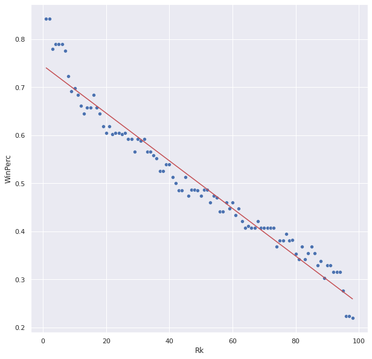

```python
sns.set(rc={"figure.figsize":(10, 10)})
ax = sns.scatterplot(x = 'Rk', y = 'WinPerc', data = teams_df)
m, b = np.polyfit(teams_df['Rk'], teams_df['WinPerc'], 1)
plt.plot(teams_df['Rk'], m*teams_df['Rk']+b, 'r')
```

Lets start by finding if Rank and Winning Percenatage. As we can see their is a negative corrolation between these two variables. The lower the rank the lower the winning percentage is.

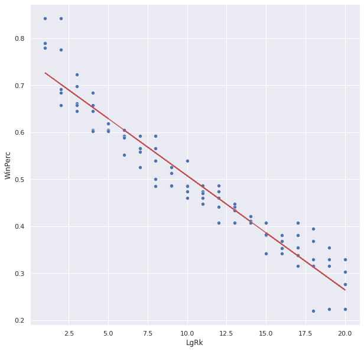

```python
sns.set(rc={"figure.figsize":(10, 10)})
ax = sns.scatterplot(x = 'LgRk', y = 'WinPerc', data = teams_df)
m, b = np.polyfit(teams_df['LgRk'], teams_df['WinPerc'], 1)
plt.plot(teams_df['LgRk'], m*teams_df['LgRk']+b, 'r')
```

The logic for the previous graph also applies to this one. Only thing is this time we are dealing with league rank.

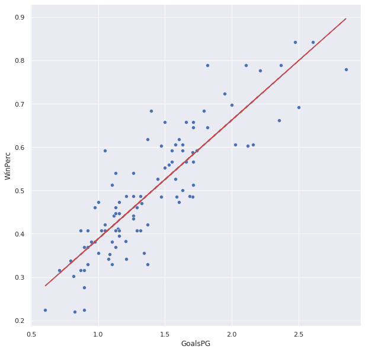

```python
sns.scatterplot(x = 'GoalsPG', y = 'WinPerc', data = teams_df)
m, b = np.polyfit(teams_df['GoalsPG'], teams_df['WinPerc'], 1)
plt.plot(teams_df['GoalsPG'], m*teams_df['GoalsPG']+b, 'r')
```

Looking at Goals per game and winning percetange, we can see there is a positive correltation. This also makes sense because the more goals a team scores the better the chance they will win.

```python
league_rank_df = teams_df.groupby('LgRk').mean()
league_rank_df.head()
```

| LgRk | Rk | MP | W | D | L | GF | GA | GD | Pts | Shots | ... | PasTotAtt | Assists | PasAss | SCA | GCA | DriSucc | DriAtt | PassPerc | DriPerc | WinPerc |
| --- | --- | --- | --- | --- | --- | --- | --- | --- | --- | --- | --- | --- | --- | --- | --- | --- | --- | --- | --- | --- | --- |
| 1 | 3.8 | 37.2 | 26.2 | 7.0 | 4.0 | 87.0 | 32.2 | 54.8 | 85.6 | 635.8 | ... | 24307.6 | 59.2 | 35.230 | 1035.4 | 136.4 | 433.8 | 766.4 | 0.865841 | 0.566505 | 0.797988 |
| 2 | 8.6 | 37.2 | 23.4 | 7.6 | 6.2 | 78.8 | 37.2 | 41.6 | 77.8 | 568.6 | ... | 23464.8 | 55.4 | 35.008 | 910.8 | 127.8 | 322.0 | 583.6 | 0.851789 | 0.550691 | 0.730341 |
| 3 | 12.6 | 37.2 | 21.0 | 8.4 | 7.8 | 72.0 | 38.8 | 33.2 | 71.4 | 502.2 | ... | 21042.0 | 49.2 | 25.368 | 815.2 | 115.2 | 357.0 | 621.4 | 0.826780 | 0.574986 | 0.677090 |
| 4 | 17.6 | 37.2 | 19.4 | 8.8 | 9.0 | 66.6 | 36.8 | 29.8 | 67.0 | 486.2 | ... | 20606.0 | 48.2 | 27.090 | 781.8 | 110.8 | 305.4 | 557.8 | 0.834576 | 0.547018 | 0.639009 |
| 5 | 22.4 | 37.2 | 19.0 | 7.4 | 10.8 | 60.4 | 45.2 | 15.2 | 64.2 | 480.0 | ... | 19268.0 | 40.4 | 24.148 | 763.2 | 92.6 | 310.0 | 572.0 | 0.811522 | 0.542017 | 0.610062 |

5 rows × 21 columns

Lets try to find similar trends if we find mean gouped by the league rank.

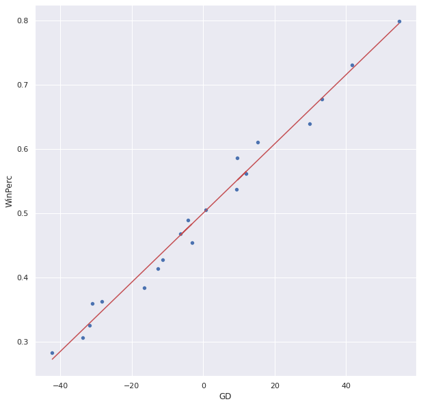

```python
ax = sns.scatterplot(x='GD', y = 'WinPerc', data = league_rank_df)
m, b = np.polyfit(league_rank_df['GD'], league_rank_df['WinPerc'], 1)
plt.plot(league_rank_df['GD'], m*league_rank_df['GD']+b, 'r')
```

Remember GD (Goal Differential) is just Goals Made minus Goals Conceded. So This is really a good indicator that a team wins more often. Notice the graph as a postive correlation. Again the higher the GD the higher winning percentage.

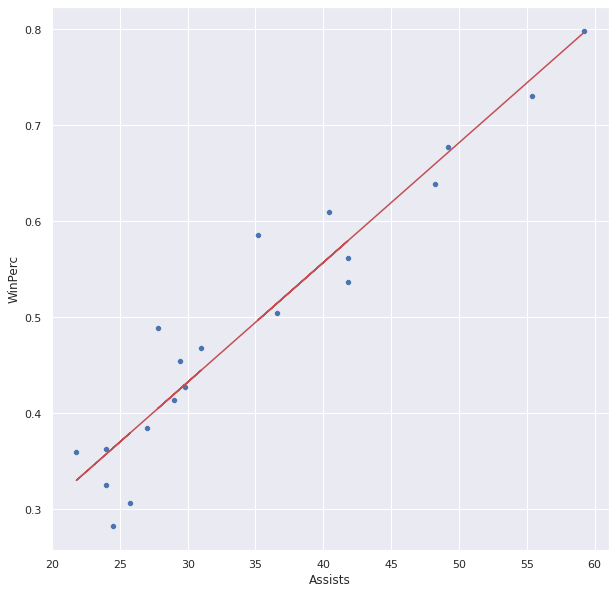

```python
sns.scatterplot(x='Assists', y = 'WinPerc', data = league_rank_df)
m, b = np.polyfit(league_rank_df['Assists'], league_rank_df['WinPerc'], 1)
plt.plot(league_rank_df['Assists'], m*league_rank_df['Assists']+b, 'r')
```

Assists also play a part in winning percentage.

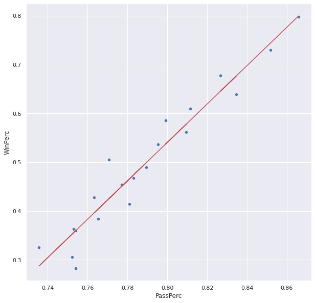

```python
sns.scatterplot(x='PassPerc', y = 'WinPerc', data = league_rank_df)
m, b = np.polyfit(league_rank_df['PassPerc'], league_rank_df['WinPerc'], 1)
plt.plot(league_rank_df['PassPerc'], m*league_rank_df['PassPerc']+b, 'r')
```

We should also look into passing stats. Of course the majority of the game is passing. How can one score if teams don't pass the ball enough. Based on the graph there is a correltation between passing and winning.

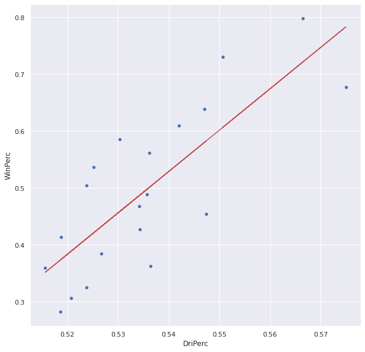

```python
sns.scatterplot(x='DriPerc', y = 'WinPerc', data = league_rank_df)
m, b = np.polyfit(league_rank_df['DriPerc'], league_rank_df['WinPerc'], 1)
plt.plot(league_rank_df['DriPerc'], m*league_rank_df['DriPerc']+b, 'r')
```

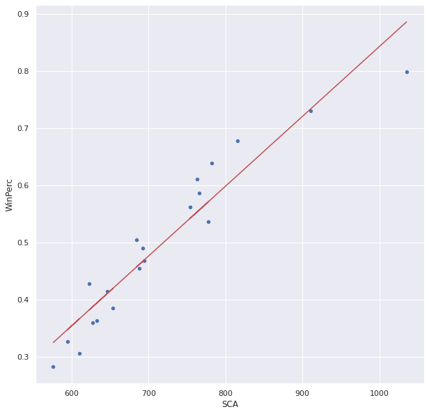

```python
sns.scatterplot(x='SCA', y = 'WinPerc', data = league_rank_df)
m, b = np.polyfit(league_rank_df['SCA'], league_rank_df['WinPerc'], 1)
plt.plot(league_rank_df['SCA'], m*league_rank_df['SCA']+b, 'r')
```

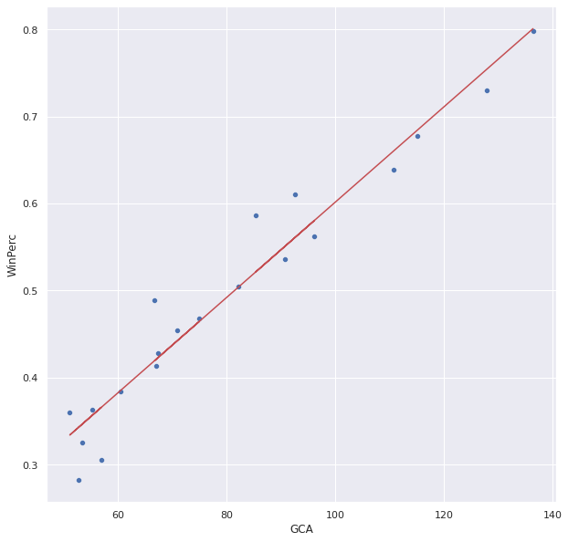

```python
sns.scatterplot(x='GCA', y = 'WinPerc', data = league_rank_df)
m, b = np.polyfit(league_rank_df['GCA'], league_rank_df['WinPerc'], 1)
plt.plot(league_rank_df['GCA'], m*league_rank_df['GCA']+b, 'r')
```

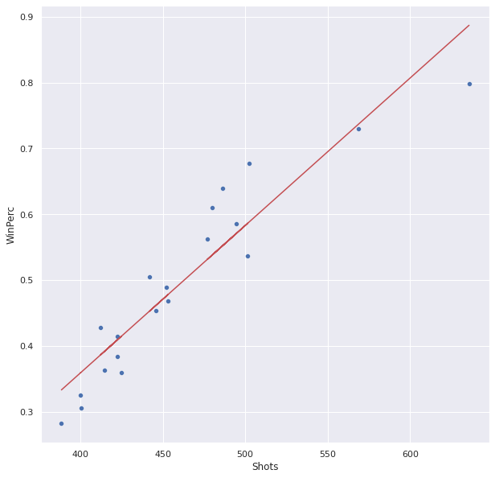

```python
sns.scatterplot(x='Shots', y = 'WinPerc', data = league_rank_df)
m, b = np.polyfit(league_rank_df['Shots'], league_rank_df['WinPerc'], 1)
plt.plot(league_rank_df['Shots'], m*league_rank_df['Shots']+b, 'r')
```

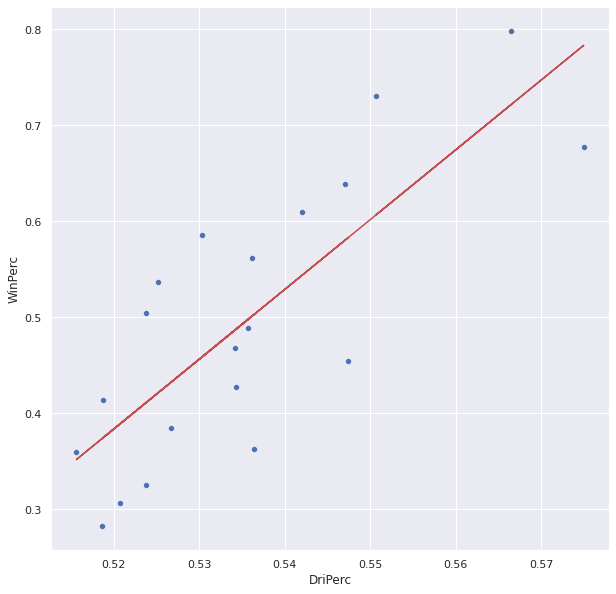

```python
sns.scatterplot(x='DriPerc', y = 'WinPerc', data = league_rank_df)
m, b = np.polyfit(league_rank_df['DriPerc'], league_rank_df['WinPerc'], 1)
plt.plot(league_rank_df['DriPerc'], m*league_rank_df['DriPerc']+b, 'r')
```

# Hypothesis Testing

Now that we have an idea what increases a teams chance of winning lets do a hypthesis test.

```python
curr_team_stats_df = pd.read_csv('2022-2023 Football Team Stats.csv', sep = ';', encoding = "ISO-8859-1")
curr_player_stats_df = pd.read_csv('2022-2023 Football Player Stats.csv', sep = ';', encoding = "ISO-8859-1")

curr_team_stats_df.drop(columns = ['Pts/MP','xG','xGA','xGD','xGD/90','Attendance','Top Team Scorer', 'Goalkeeper'], inplace = True)
curr_player_complete_stats_df = curr_player_stats_df [['Squad', 'Goals','Min', 'Shots', 'SoT','PasTotCmp','PasTotAtt','Assists','PasAss','SCA','GCA','DriSucc','DriAtt']]

for i,d in curr_player_stats_df.iterrows():
    curr_player_complete_stats_df.at[i,'Goals'] = round((d['Goals'] * d['Min']) / 90)
    curr_player_complete_stats_df.at[i,'Assists'] = round((d['Assists'] * d['Min']) / 90)
    curr_player_complete_stats_df.at[i,'Shots'] = round((d['Shots'] * d['Min']) / 90)
    curr_player_complete_stats_df.at[i,'PasTotCmp'] = round((d['PasTotCmp'] * d['Min']) / 90)
    curr_player_complete_stats_df.at[i,'PasTotAtt'] = round((d['PasTotAtt'] * d['Min']) / 90)
    curr_player_complete_stats_df.at[i,'SCA'] = round((d['SCA'] * d['Min']) / 90)
    curr_player_complete_stats_df.at[i,'GCA'] = round((d['GCA'] * d['Min']) / 90)
    curr_player_complete_stats_df.at[i,'DriSucc'] = round((d['DriSucc'] * d['Min']) / 90)
    curr_player_complete_stats_df.at[i,'DriAtt'] = round((d['DriAtt'] * d['Min']) / 90)

curr_player_complete_stats_df = curr_player_complete_stats_df.groupby('Squad',as_index=False).sum()

curr_teams_df = curr_team_stats_df.merge(curr_player_complete_stats_df, how ='left', on = 'Squad')

curr_teams_df = curr_teams_df.assign(PassPerc = curr_teams_df['PasTotCmp'] / curr_teams_df['PasTotAtt'])

curr_teams_df = curr_teams_df.assign(DriPerc = curr_teams_df['DriSucc'] / curr_teams_df['DriAtt'])

curr_teams_df = curr_teams_df.assign(GoalsPG = curr_teams_df['GF'] / curr_teams_df['MP'])

curr_teams_df = curr_teams_df.assign(AssistsPG = curr_teams_df['Assists'] / curr_teams_df['MP'])

curr_teams_df = curr_teams_df.assign(WinPerc = (curr_teams_df['W'] + curr_teams_df['D'] * 0.5) / curr_teams_df['MP'])

curr_teams_df.drop(columns = ['MP', 'W','D','L'], inplace = True)

curr_teams_df.head(10)
```

|  | Rk | Squad | Country | LgRk | GF | GA | GD | Pts | Goals | Min | ... | PasAss | SCA | GCA | DriSucc | DriAtt | PassPerc | DriPerc | GoalsPG | AssistsPG | WinPerc |
| --- | --- | --- | --- | --- | --- | --- | --- | --- | --- | --- | --- | --- | --- | --- | --- | --- | --- | --- | --- | --- | --- |
| 0 | 1 | Paris S-G | FRA | 1 | 43 | 9 | 34 | 41 | 42.0 | 14800 | ... | 24.69 | 413.0 | 69.0 | 172.0 | 400.0 | 0.894198 | 0.430000 | 2.866667 | 2.133333 | 0.933333 |
| 1 | 2 | Napoli | ITA | 1 | 37 | 12 | 25 | 41 | 37.0 | 14850 | ... | 28.26 | 488.0 | 68.0 | 108.0 | 295.0 | 0.852961 | 0.366102 | 2.466667 | 2.066667 | 0.933333 |
| 2 | 3 | Barcelona | ESP | 1 | 33 | 5 | 28 | 37 | 33.0 | 13799 | ... | 25.38 | 427.0 | 59.0 | 135.0 | 292.0 | 0.871281 | 0.462329 | 2.357143 | 1.642857 | 0.892857 |
| 3 | 4 | Arsenal | ENG | 1 | 33 | 11 | 22 | 37 | 32.0 | 13860 | ... | 24.39 | 389.0 | 57.0 | 127.0 | 270.0 | 0.835165 | 0.470370 | 2.357143 | 1.714286 | 0.892857 |
| 4 | 5 | Real Madrid | ESP | 2 | 33 | 14 | 19 | 35 | 33.0 | 13859 | ... | 33.12 | 455.0 | 59.0 | 128.0 | 269.0 | 0.884912 | 0.475836 | 2.357143 | 1.714286 | 0.857143 |
| 5 | 6 | Lens | FRA | 2 | 26 | 10 | 16 | 36 | 26.0 | 14825 | ... | 23.98 | 379.0 | 45.0 | 120.0 | 247.0 | 0.843979 | 0.485830 | 1.733333 | 1.400000 | 0.833333 |
| 6 | 7 | Manchester City | ENG | 2 | 40 | 14 | 26 | 32 | 39.0 | 13795 | ... | 24.42 | 445.0 | 73.0 | 111.0 | 240.0 | 0.876109 | 0.462500 | 2.857143 | 2.285714 | 0.785714 |
| 7 | 8 | Bayern Munich | GER | 1 | 49 | 13 | 36 | 34 | 48.0 | 14849 | ... | 46.48 | 520.0 | 78.0 | 152.0 | 335.0 | 0.854946 | 0.453731 | 3.266667 | 2.200000 | 0.800000 |
| 8 | 9 | Milan | ITA | 2 | 29 | 15 | 14 | 33 | 27.0 | 14805 | ... | 27.07 | 433.0 | 46.0 | 119.0 | 271.0 | 0.794779 | 0.439114 | 1.933333 | 1.466667 | 0.766667 |
| 9 | 10 | Juventus | ITA | 3 | 24 | 7 | 17 | 31 | 24.0 | 14796 | ... | 26.51 | 339.0 | 37.0 | 75.0 | 189.0 | 0.819166 | 0.396825 | 1.600000 | 1.266667 | 0.733333 |

10 rows × 25 columns

Before we do any hypothesis testing we want to predict this leagues winner with using the stats from the current season. So we perfrom the same modifcations that was done from the other datasets, with these two new datas. These dataset will have stats from the 2022-2023 season. The dataset can be found [here](https://www.kaggle.com/datasets/vivovinco/20222023-football-player-stats) and [here](https://www.kaggle.com/datasets/vivovinco/20222023-football-team-stats)

```python
x_columns = ['GoalsPG', 'AssistsPG','PassPerc']
x = teams_df[x_columns]
y = teams_df.Rk

clf = tree.DecisionTreeClassifier()
x_train, x_test, y_train, y_test = train_test_split(x, y, test_size=0.3, random_state=0)
clf = clf.fit(x_train,y_train)
clf.score(x,y)
```

```
0.6938775510204082
```

We will use a decision tree to classify a possible winner. A tutorial on how to implement the decision tree can be found [here](https://www.datacamp.com/tutorial/decision-tree-classification-python). The depended variables that will be used are GoalsPG, AssistsPG, and PassPerc. And since we want to find a winner, the rank will be the inpendent variable. You can see the accuracy score is 0.69. This is an ok accuracy score.

```python
for t in curr_teams_df['Squad'].tolist():
    team = curr_teams_df[curr_teams_df['Squad'] == t]
    print(str(t) + ' -> Possible Position: ' + str(clf.predict(team[x_columns])))
```

```
Paris S-G -> Possible Position: [1]
Napoli -> Possible Position: [2]
Barcelona -> Possible Position: [1]
Arsenal -> Possible Position: [2]
Real Madrid -> Possible Position: [1]
Lens -> Possible Position: [11]
Manchester City -> Possible Position: [1]
Bayern Munich -> Possible Position: [2]
Milan -> Possible Position: [15]
Juventus -> Possible Position: [19]
Rennes -> Possible Position: [24]
Newcastle Utd -> Possible Position: [41]
Lazio -> Possible Position: [33]
Marseille -> Possible Position: [42]
Inter -> Possible Position: [22]
Freiburg -> Possible Position: [41]
Tottenham -> Possible Position: [22]
RB Leipzig -> Possible Position: [24]
Lorient -> Possible Position: [15]
Real Sociedad -> Possible Position: [21]
Manchester Utd -> Possible Position: [38]
Monaco -> Possible Position: [15]
Eint Frankfurt -> Possible Position: [41]
Atalanta -> Possible Position: [38]
Union Berlin -> Possible Position: [37]
Roma -> Possible Position: [40]
Lille -> Possible Position: [13]
Athletic Club -> Possible Position: [15]
Atlético Madrid -> Possible Position: [36]
Betis -> Possible Position: [40]
Dortmund -> Possible Position: [42]
Osasuna -> Possible Position: [39]
Udinese -> Possible Position: [37]
Liverpool -> Possible Position: [22]
Rayo Vallecano -> Possible Position: [38]
Wolfsburg -> Possible Position: [37]
Villarreal -> Possible Position: [30]
Brighton -> Possible Position: [28]
Chelsea -> Possible Position: [21]
M'Gladbach -> Possible Position: [13]
```

[output cut: 43 more lines]

```
Bochum -> Possible Position: [85]
Espanyol -> Possible Position: [50]
Celta Vigo -> Possible Position: [84]
Ajaccio -> Possible Position: [92]
Southampton -> Possible Position: [93]
Sevilla -> Possible Position: [84]
Cádiz -> Possible Position: [97]
Strasbourg -> Possible Position: [60]
Wolves -> Possible Position: [97]
Schalke 04 -> Possible Position: [88]
Angers -> Possible Position: [30]
Cremonese -> Possible Position: [94]
Sampdoria -> Possible Position: [97]
Hellas Verona -> Possible Position: [88]
Elche -> Possible Position: [90]
```

It looks like the possible winners will be Paris S-G, Barcelona,Real Madrid, or Manchester City

```python
clf = RandomForestClassifier(n_estimators = 100)
clf.fit(x_train,y_train)
clf.score(x,y)
```

```
0.6938775510204082
```

Now lets try to find a winner again but this time using the random forest algorithm. This should proved a more accurate result because it will run 100 trees to find the possible winner(s).

```python
for t in curr_teams_df['Squad'].tolist():
    team = curr_teams_df[curr_teams_df['Squad'] == t]
    print(str(t) + ' -> Possible Position: ' + str(clf.predict(team[x_columns])))
```

```
Paris S-G -> Possible Position: [1]
Napoli -> Possible Position: [2]
Barcelona -> Possible Position: [1]
Arsenal -> Possible Position: [2]
Real Madrid -> Possible Position: [1]
Lens -> Possible Position: [11]
Manchester City -> Possible Position: [1]
Bayern Munich -> Possible Position: [2]
Milan -> Possible Position: [15]
Juventus -> Possible Position: [19]
Rennes -> Possible Position: [24]
Newcastle Utd -> Possible Position: [41]
Lazio -> Possible Position: [33]
Marseille -> Possible Position: [42]
Inter -> Possible Position: [22]
Freiburg -> Possible Position: [41]
Tottenham -> Possible Position: [22]
RB Leipzig -> Possible Position: [24]
Lorient -> Possible Position: [15]
Real Sociedad -> Possible Position: [21]
Manchester Utd -> Possible Position: [38]
Monaco -> Possible Position: [15]
Eint Frankfurt -> Possible Position: [41]
Atalanta -> Possible Position: [38]
Union Berlin -> Possible Position: [37]
Roma -> Possible Position: [40]
Lille -> Possible Position: [13]
Athletic Club -> Possible Position: [15]
Atlético Madrid -> Possible Position: [36]
Betis -> Possible Position: [40]
Dortmund -> Possible Position: [42]
Osasuna -> Possible Position: [39]
Udinese -> Possible Position: [37]
Liverpool -> Possible Position: [22]
Rayo Vallecano -> Possible Position: [38]
Wolfsburg -> Possible Position: [37]
Villarreal -> Possible Position: [30]
Brighton -> Possible Position: [28]
Chelsea -> Possible Position: [21]
M'Gladbach -> Possible Position: [13]
```

[output cut: 43 more lines]

```
Bochum -> Possible Position: [85]
Espanyol -> Possible Position: [50]
Celta Vigo -> Possible Position: [84]
Ajaccio -> Possible Position: [92]
Southampton -> Possible Position: [93]
Sevilla -> Possible Position: [84]
Cádiz -> Possible Position: [97]
Strasbourg -> Possible Position: [60]
Wolves -> Possible Position: [97]
Schalke 04 -> Possible Position: [88]
Angers -> Possible Position: [30]
Cremonese -> Possible Position: [94]
Sampdoria -> Possible Position: [97]
Hellas Verona -> Possible Position: [88]
Elche -> Possible Position: [90]
```

Based on this algorithm it looks like we kept the same result. In that Paris, Barcelona, Real Madrid, and Manchester City would be the possible winners.

# Conclusions

So in the end we manage to find the same winner for both algorithms. We begged to ask to the question how much would the results change if we added more data. Meaning adding more seasons to our dataset. However, the winner that were found are actucally believable in a real life envorinment because those teams are acutally considered the best in the world.